# Tutorial for `MDRefine` - 3

In these notebooks we are going to perform several different refinements of MD-generated trajectories by employing the package `MDRefine`. In this way, we believe the usage of `MDRefine` will become clear and easy to emulate for your own case of interest. Input data for these examples may be downloaded from Zenodo as indicated in `load_data_oligomers.ipynb`.

We remind you to have a look at our paper https://arxiv.org/pdf/2411.07798 and at the documentation https://www.bussilab.org/doc-MDRefine/MDRefine/index.html.

Required assistance may be opened at https://github.com/bussilab/MDRefine/issues.

```python
# install matplotlib and other dependencies
!pip install -r requirements.txt
```

```python
import pandas
import os
import numpy as np
import jax.numpy as jnp
import matplotlib
import matplotlib.pyplot as plt
```

```python
# import from parent directory
import sys
sys.path.insert(0, '../')

import MDRefine

print("I will use the MDRefine version installed at", MDRefine.__file__)
```

```
I will use the MDRefine version installed at /home/runner/work/MDRefine/MDRefine/Examples/../MDRefine/__init__.py
```

```python
from MDRefine import load_data, split_dataset, minimizer, hyper_minimizer, MDRefinement, compute_chi2
```

## Usage of `MDRefinement`

Let's see an application of `MDRefinement`, which includes automatic optimization of the hyperparameters, for the refinement of RNA oligomers. This function `MDRefinement` includes both `load_data`, the cross validation procedure (with automatic minimization of the $\chi^2$ on left-out observables / frames) and `minimizer`.

```python
%%bash

if [ ! -d "DATA" ]; then
    curl -O https://zenodo.org/records/14956459/files/DATA.zip

    unzip DATA.zip
    rm -r DATA.zip
fi
```

### Load data

Just to show an example of how `MDRefinement` works, you can take 2 molecular systems (AAAA and CAAU, for instance) and avoid loading the unobserved NOEs, which are computationally expensive.

```python
infos = {'global': {
    'path_directory': 'DATA',
    'system_names': ['AAAA', 'CAAU'], #, 'CCCC', 'GACC', 'UUUU', 'UCAAUC'],
    'g_exp': ['backbone1_gamma_3J', 'backbone2_beta_epsilon_3J', 'sugar_3J', 'NOEs'],  #  , ('uNOEs', '<')],
    'forward_qs': ['backbone1_gamma', 'backbone2_beta_epsilon','sugar'],
    'obs': ['NOEs'],  # , 'uNOEs'],
    'forward_coeffs': 'original_fm_coeffs'}}

stride = 1  # 00
```

- define the forward model (include also the possibility for selected_obs, namely, to compute only selected observables in cross validation)

```python
def forward_model_fun(fm_coeffs, forward_qs, selected_obs=None):

    # 1. compute the cosine (which is the quantity you need in the forward model;
    # you could do this just once before loading data)
    forward_qs_cos = {}

    for type_name in forward_qs.keys():
        forward_qs_cos[type_name] = jnp.cos(forward_qs[type_name])

    # if you have selected_obs, compute only the corresponding observables
    if selected_obs is not None:
        for type_name in forward_qs.keys():
            forward_qs_cos[type_name] = forward_qs_cos[type_name][:, selected_obs[type_name + '_3J']]

    # 2. compute observables (forward_qs_out) through forward model
    forward_qs_out = {
        'backbone1_gamma_3J': fm_coeffs[0]*forward_qs_cos['backbone1_gamma']**2 + fm_coeffs[1]*forward_qs_cos['backbone1_gamma'] + fm_coeffs[2],
        'backbone2_beta_epsilon_3J': fm_coeffs[3]*forward_qs_cos['backbone2_beta_epsilon']**2 + fm_coeffs[4]*forward_qs_cos['backbone2_beta_epsilon'] + fm_coeffs[5],
        'sugar_3J': fm_coeffs[6]*forward_qs_cos['sugar']**2 + fm_coeffs[7]*forward_qs_cos['sugar'] + fm_coeffs[8] }

    return forward_qs_out
```

```python
infos['global']['forward_model'] = forward_model_fun
```

- choose among force-field correction on $\alpha,\zeta$ or only on $\alpha$ dihedral angles, for example let's take the second

```python
infos['global']['names_ff_pars'] = ['sin alpha', 'cos alpha']

def ff_correction(pars, f):
    out = jnp.matmul(pars, (f[:, [0, 6]] + f[:, [1, 7]] + f[:, [2, 8]]).T)
    return out

def ff_correction_hexamers(pars, f):
    out = jnp.matmul(pars, (f[:, [0, 10]] + f[:, [1, 11]] + f[:, [2, 12]] + f[:, [3, 13]] + f[:, [4, 14]]).T)
    return out

infos['global']['ff_correction'] = ff_correction
infos['UCAAUC'] = {'ff_correction': ff_correction_hexamers}
```

- load the data

```python
data = load_data(infos, stride=stride)
```

```
loading data from directory...
loading  AAAA
loading  CAAU
```

```
done
```

- define also the regularizations of the forward model (user-defined) and the force-field correction (Kullback-Leibler divergence)

```python
def forward_model_regularization(coeffs, coeffs_0):
    regularization = (
    3/8*(coeffs[0]-coeffs_0['A_gamma'])**2+1/2*(coeffs[1]-coeffs_0['B_gamma'])**2+(coeffs[2]-coeffs_0['C_gamma'])**2+(coeffs[0]-coeffs_0['A_gamma'])*(coeffs[2]-coeffs_0['C_gamma'])+
    3/8*(coeffs[3]-coeffs_0['A_beta'])**2+1/2*(coeffs[4]-coeffs_0['B_beta'])**2+(coeffs[5]-coeffs_0['C_beta'])**2+(coeffs[3]-coeffs_0['A_beta'])*(coeffs[5]-coeffs_0['C_beta'])+
    3/8*(coeffs[6]-coeffs_0['A_sugar'])**2+1/2*(coeffs[7]-coeffs_0['B_sugar'])**2+(coeffs[8]-coeffs_0['C_sugar'])**2+(coeffs[6]-coeffs_0['A_sugar'])*(coeffs[8]-coeffs_0['C_sugar']))

    return regularization
```

```python
regularization = {'force_field_reg': 'KL divergence', 'forward_model_reg': forward_model_regularization}
```

### Case 1: ensemble + forward-model refinement

Apply separately `hyper_minimizer` and then `minimizer` at optimal values of the hyperparameters, or just `MDRefinement`. Then, analyse the results.

```python
starting_alpha = 1
starting_beta = np.inf
starting_gamma = 1

which_set = 'validation'
random_states = 2
```

#### a. search for the optimal hyperparameters

- select starting values for the hyperparameters ($+\infty$ if no refinement in that direction);
- select also how to optimize the hyperparameters, namely, if you want to minimize the $\chi^2$ on `which_set = 'valid_frames'` (left-out frames) or `'validation'` (left-out observables); `'validation'` by default;
- select `random_states`, namely, how many splitting in cross validation.

```python
hyper_out = hyper_minimizer(data, regularization=regularization, starting_alpha=starting_alpha,
    starting_beta=starting_beta, starting_gamma=starting_gamma, random_states=random_states,
    which_set='validation')
```

[output not shown]

```
Input random_state employed both for observables and frames
```

```
log10 hyperpars:  [('alpha', np.float64(0.0)), ('gamma', np.float64(0.0))]
```

```
av. chi2:  2032.006896091705
av. gradient:  [-214.79408982   33.49478631]

log10 hyperpars:  [('alpha', np.float64(0.9880588499116885)), ('gamma', np.float64(-0.1540769584045304))]
```

```
av. chi2:  171.61038911741974
av. gradient:  [-950.25710416    8.12683438]

log10 hyperpars:  [('alpha', np.float64(4.940294249558442)), ('gamma', np.float64(-0.770384792022652))]
```

```
av. chi2:  158.73165150299178
av. gradient:  [0.57305898 0.96748758]

log10 hyperpars:  [('alpha', np.float64(4.92725954782415)), ('gamma', np.float64(-0.7925662915473703))]
```

```
av. chi2:  158.70295351425682
av. gradient:  [0.59043033 0.8965849 ]

log10 hyperpars:  [('alpha', np.float64(4.875120740886981)), ('gamma', np.float64(-0.8812922896462438))]
```

```
av. chi2:  158.6017467017124
av. gradient:  [0.66535714 0.66012424]
```

```python
opt_alpha, opt_gamma = 10**hyper_out.x

print(opt_alpha, opt_gamma)
```

```
75010.27210292662 0.1314339955035782
```

#### b. search for optimal coefficients at optimized hyperparameters

```python
Result = minimizer(data, regularization=regularization, alpha=opt_alpha, gamma=opt_gamma)
```

[output not shown]

```python
print(vars(Result).keys())

tot_chi2 = np.sum([item2 for item in Result.chi2.values() for item2 in item.values()])
print('1/2 chi2: ', 1/2*tot_chi2)

print('gamma*R: ', opt_gamma*Result.reg_fm)

tot_DKL = np.sum([l for l in Result.D_KL_alpha.values()])
print('alpha*D_KL: ', opt_alpha*tot_DKL)

loss = opt_gamma*Result.reg_fm + opt_alpha*tot_DKL + 1/2*tot_chi2
print('loss: ', loss)
```

```
dict_keys(['loss', 'pars', 'mini', 'min_lambdas', 'minis', 'intermediates', 'time', 'reg_fm', 'D_KL_alpha', 'abs_difference', 'av_g', 'chi2', 'logZ_new', 'weights_new'])
1/2 chi2:  92.73690959935388
gamma*R:  0.5751698526810012
alpha*D_KL:  0.07807943777634319
loss:  93.39015888981122
```

```python
fm_names = list(data.properties.forward_coeffs_0.keys())
my_fm_coeffs = pandas.Series(Result.pars[-len(fm_names):], index=fm_names)
print(my_fm_coeffs)
```

```
A_gamma     9.884338
B_gamma    -1.889158
C_gamma    -0.176545
A_beta     19.571481
B_beta     -4.981750
C_beta     -0.390388
A_sugar     8.729670
B_sugar    -1.320175
C_sugar    -0.564849
dtype: float64
```

#### c. `MDRefinement`

you can do a. and b. at once with `MDRefinement`

```python
result = MDRefinement(data, stride=stride, regularization=regularization, starting_alpha=starting_alpha, starting_beta=starting_beta,
    starting_gamma=starting_gamma, random_states=random_states, which_set=which_set, results_folder_name='my_results')  # , gtol=0.1, ftol=0.001)
```

[output not shown]

```
Input random_state employed both for observables and frames
```

```
log10 hyperpars:  [('alpha', np.float64(0.0)), ('gamma', np.float64(0.0))]
```

```
av. chi2:  2032.006896091705
av. gradient:  [-214.79408982   33.49478631]

log10 hyperpars:  [('alpha', np.float64(0.9880588499116885)), ('gamma', np.float64(-0.1540769584045304))]
```

```
av. chi2:  171.61038911741974
av. gradient:  [-950.25710416    8.12683438]

log10 hyperpars:  [('alpha', np.float64(4.940294249558442)), ('gamma', np.float64(-0.770384792022652))]
```

```
av. chi2:  158.73165150299178
av. gradient:  [0.57305898 0.96748758]

log10 hyperpars:  [('alpha', np.float64(4.92725954782415)), ('gamma', np.float64(-0.7925662915473703))]
```

```
av. chi2:  158.70295351425682
av. gradient:  [0.59043033 0.8965849 ]

log10 hyperpars:  [('alpha', np.float64(4.875120740886981)), ('gamma', np.float64(-0.8812922896462438))]
```

```
av. chi2:  158.6017467017124
av. gradient:  [0.66535714 0.66012424]

optimal hyperparameters: alpha: 75010.27210292662 gamma: 0.1314339955035782

refinement with optimal hyperparameters...
```

```
done
```

### Case 2: fully combined

Now, let's use directly `MDRefinement`, starting with $\beta = 1$ rather than $+\infty$.

The results will be saved in the folder `my_results`, together with those of the previous run of `MDrefinement` in the above cell.

```python
starting_alpha = 1
starting_beta = 1
starting_gamma = 1

which_set = 'validation'
random_states = 5
```

```python
result2 = MDRefinement(data, stride=stride, regularization=regularization, starting_alpha=starting_alpha, starting_beta=starting_beta,
    starting_gamma=starting_gamma, random_states=random_states, which_set=which_set, results_folder_name='my_results')  # , gtol=0.1, ftol=0.001)
```

[output not shown]

```
Input random_state employed both for observables and frames
```

```
Input random_state employed both for observables and frames
```

```
Input random_state employed both for observables and frames
```

```
Input random_state employed both for observables and frames
```

```
log10 hyperpars:  [('alpha', np.float64(0.0)), ('beta', np.float64(0.0)), ('gamma', np.float64(0.0))]
```

```
av. chi2:  1454.4822140966244
av. gradient:  [-2974.08168756  -117.43365448   436.41804338]

log10 hyperpars:  [('alpha', np.float64(0.9886502537850727)), ('beta', np.float64(0.039037533093050844)), ('gamma', np.float64(-0.14507496924252822))]
```

```
av. chi2:  95.81365088430277
av. gradient:  [-502.41693789  -61.07122695  -13.21799628]

log10 hyperpars:  [('alpha', np.float64(1.1912975270111688)), ('beta', np.float64(0.06668262868567869)), ('gamma', np.float64(-0.13339182266384567))]
```

```
av. chi2:  43.79372275491727
av. gradient:  [-63.58441806  -1.89942216   1.85310162]

log10 hyperpars:  [('alpha', np.float64(1.220607553050835)), ('beta', np.float64(0.06762502785151588)), ('gamma', np.float64(-0.133517059280179))]
```

```
av. chi2:  42.41312930436415
av. gradient:  [-32.86715199   0.35651578   2.38658977]

optimal hyperparameters: alpha: 16.619101989543875 beta: 1.1684900748585763 gamma: 0.7353311107754094

refinement with optimal hyperparameters...
```

```
done
```

```python
print(vars(result2).keys())

print(result2.optimal_hyperpars)

opt_alpha = result2.optimal_hyperpars['alpha']
opt_beta = result2.optimal_hyperpars['beta']
opt_gamma = result2.optimal_hyperpars['gamma']
```

```
dict_keys(['loss', 'pars', 'mini', 'min_lambdas', 'minis', 'intermediates', 'time', 'weights_P', 'logZ_P', 'reg_ff', 'reg_fm', 'D_KL_alpha', 'abs_difference', 'av_g', 'chi2', 'logZ_new', 'weights_new', 'optimal_hyperpars', 'hyper_minimization'])
{'alpha': np.float64(16.619101989543875), 'beta': np.float64(1.1684900748585763), 'gamma': np.float64(0.7353311107754094)}
```

```python
if not np.isinf(opt_beta):
    temp = infos['global']['names_ff_pars']
    my_ff_coeffs = pandas.Series(result2.pars[:len(temp)], index=temp)
    print(my_ff_coeffs)

if not np.isinf(opt_gamma):
    fm_names = list(data.properties.forward_coeffs_0.keys())
    my_fm_coeffs = pandas.Series(result2.pars[-len(fm_names):], index=fm_names)
    print(my_fm_coeffs)
```

```
sin alpha    0.279016
cos alpha   -0.501551
dtype: float64
A_gamma     9.968221
B_gamma    -1.852384
C_gamma    -0.146915
A_beta     18.221124
B_beta     -5.392253
C_beta      0.226742
A_sugar     9.268215
B_sugar    -1.443631
C_sugar    -0.678919
dtype: float64
```

```python
fm_coeffs_0 = pandas.read_csv('Results/original_fm_coeffs', index_col=0, header=None)[1]
fm_coeffs_Thorben = pandas.read_csv('Results/fm_coeffs_Thorben_ref', index_col=0, header=None)[1]

# hyperparameters derived by Thorben with chi2 and chi2 + R regularizations respectively
mini1_hyperpars = {'alpha': 85.3167852417281, 'beta': 0.019306977288832506*2}
mini2_hyperpars = {'alpha': 174.33288221999874, 'beta': 3.433320018281997*2} # those for fm_coeffs_Thorben

fm_coeffs = {'original': fm_coeffs_0, 'Thorben': fm_coeffs_Thorben, 'mine': my_fm_coeffs}
```

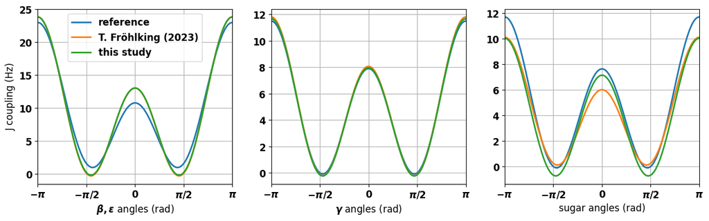

```python
font = {'weight' : 'bold', 'size' : 12}

# plt.rcdefaults()
matplotlib.rc('font', **font)
matplotlib.rcParams['lines.linewidth'] = 2
matplotlib.rcParams['lines.markersize'] = 10

fig, axs = plt.subplots(nrows=1, ncols=3)
fig.set_figheight(4)
fig.set_figwidth(15)

compute_j_coupl = lambda fm_coeffs, angles, s: fm_coeffs['A_' + s]*np.cos(angles)**2 + fm_coeffs['B_' + s]*np.cos(angles) + fm_coeffs['C_' + s]*np.ones(len(angles))

# plt.suptitle(r'Refinement of Karplus equations $\alpha=%.2f,\beta=%.2f,\gamma=%.2f$' % (opt_alpha, opt_beta, opt_gamma))

angles = np.linspace(-np.pi, np.pi, 100)
titles = [r'$\beta,\epsilon$', r'$\gamma$', 'sugar']

for i,s in enumerate(['beta', 'gamma', 'sugar']):

    j_coupl = {}

    j_coupl = compute_j_coupl(fm_coeffs['original'], angles, s)
    axs[i].plot(angles, j_coupl, '-', label='reference')

    j_coupl = compute_j_coupl(fm_coeffs['Thorben'], angles, s)
    axs[i].plot(angles, j_coupl, '-', label='T. Fröhlking (2023)')

    j_coupl = compute_j_coupl(fm_coeffs['mine'], angles, s) #  ['mean'], angles, s)
    axs[i].plot(angles, j_coupl, '-', label='this study') #   (average)')

    # j_coupl = compute_j_coupl(fm_coeffs['100 optimal'], angles, s) #  ['mean'], angles, s)
    # axs[i].plot(angles, j_coupl, '-', label='this study 2') #   (average)')

    # for j in range(n_seeds):
    #     j_coupl = compute_j_coupl(fm_coeffs['mine'][j], angles, s)
    #     axs[i].plot(angles, j_coupl, '-', color='tab:red')#, label='av. mine')


    # for k in ['original', 'mini2', 'mine']:
    #     j_coupl[k] = fm_coeffs[k]['A_' + s]*np.cos(angles)**2 + fm_coeffs[k]['B_' + s]*np.cos(
    #         angles) + fm_coeffs[k]['C_' + s]*np.ones(len(angles))

    #     axs[i].plot(angles, j_coupl[k], '-', label=k)

    axs[i].grid()
    axs[i].set_xlabel(titles[i] + ' angles (rad)')
    # axs[i].set_title(titles[i])
    axs[i].set_xlim([-np.pi, np.pi])
    axs[i].set_xticks([-np.pi, -np.pi/2, 0, np.pi/2, np.pi])
    axs[i].set_xticklabels([r'$-\pi$', r'$-\pi/2$', '0', '$\pi/2$', '$\pi$'])

axs[0].legend()
axs[0].set_ylabel('J coupling (Hz)')

# plt.savefig('../Figures/Karplus_refinement_overall.png')
plt.show()
```

## Analysis of the results

Compare results from HPC calculations performed on the cluster as explained in the paper https://arxiv.org/pdf/2411.07798, stored in the `Examples/Results` directories.

#### loading values

load from external folders containing results of previous cells

```python
system_names = ['AAAA', 'CAAU', 'CCCC', 'GACC', 'UUUU', 'UCAAUC']
```

```python
path = 'Results'
dir_list = os.listdir(path)

dir_list
```

```
['2_Result_last_2024_10_03_12_35_46_920644',
 'original_fm_coeffs',
 '6_Result_2025_03_26_00_37_48',
 'my_results_2025_03_10_11_09_18_031724',
 'fm_coeffs_Thorben_ref',
 '2_Result_last_2024_10_01_13_36_53_483051',
 'alchemical_calculations',
 '6_Result_2025_03_26_03_45_28',
 'my_results_2025_03_10_12_56_41_399663']
```

```python
my_str = '2_Result_last_'
my_list = [s for s in dir_list if s.startswith(my_str)]
df_input = pandas.concat([pandas.read_csv(path + '/' + s + '/' 'input', index_col=0) for s in my_list])

df_input = df_input.sort_values(by='ftol')

df_input
```

|  | stride | starting_alpha | starting_beta | starting_gamma | random_states | which_set | gtol | ftol |
| --- | --- | --- | --- | --- | --- | --- | --- | --- |
| 2024_10_03_12_35_46_920644 | 100 | 1 | 1.0 | 1 | [1, 2, 3, 4, 5] | test | 0.5 | 0.00001 |
| 2024_10_01_13_36_53_483051 | 100 | 1 | inf | 1 | [1, 2, 3, 4, 5] | test | 0.5 | 0.00001 |

```python
my_list = df_input.index

my_list
```

```
Index(['2024_10_03_12_35_46_920644', '2024_10_01_13_36_53_483051'], dtype='object')
```

```python
my_df = pandas.concat([pandas.read_csv(path + '/' + my_str + s + '/result', index_col=0) for s in my_list])
my_df[['optimal alpha', 'optimal beta', 'optimal gamma']]
```

|  | optimal alpha | optimal beta | optimal gamma |
| --- | --- | --- | --- |
| 2024_10_03_12_35_46_920644 | 959.856495 | 167.935942 | 0.421759 |
| 2024_10_01_13_36_53_483051 | 46.308959 | NaN | 0.958824 |

```python
# my_list = [df_input.iloc[-3].name, df_input.iloc[-1].name]  # stride = 10
# my_list = [df_input.iloc[0].name, df_input.iloc[1].name]  # stride = 100
my_list = ['2024_10_01_13_36_53_483051', '2024_10_03_12_35_46_920644']

# ER+FFR and ER+FFR+FMR
df_result = pandas.concat([
    pandas.read_csv(path + '/' + my_str + my_list[1] + '/' + 'result', index_col=0),  # ER+FMR+FFR
    pandas.read_csv(path + '/' + my_str + my_list[0] + '/' + 'result', index_col=0)  # ER+FMR
    ])

df_result.index = ['E+FM+FF ref', 'E+FM ref']
df_result
```

|  | loss | sin alpha | cos alpha | A_gamma | B_gamma | C_gamma | A_beta | B_beta | C_beta | A_sugar | ... | chi2_AAAA | chi2_CAAU | chi2_CCCC | chi2_GACC | chi2_UUUU | chi2_UCAAUC | optimal alpha | optimal beta | optimal gamma | hyper_mini success |
| --- | --- | --- | --- | --- | --- | --- | --- | --- | --- | --- | --- | --- | --- | --- | --- | --- | --- | --- | --- | --- | --- |
| E+FM+FF ref | 1765.300623 | 0.584072 | -0.791454 | 9.915804 | -1.757341 | -0.116239 | 18.128530 | -5.288647 | 0.07166 | 6.986191 | ... | 120.535372 | 98.730666 | 56.247744 | 31.282016 | 178.522105 | 805.854758 | 959.856495 | 167.935942 | 0.421759 | True |
| E+FM ref | 381.026229 | NaN | NaN | 9.950988 | -1.858315 | -0.107576 | 18.907471 | -5.230515 | -0.21221 | 8.335141 | ... | 43.166862 | 29.767058 | 18.449176 | 19.622261 | 24.415580 | 214.539056 | 46.308959 | NaN | 0.958824 | True |

2 rows × 44 columns

#### plot forward-model and force-field corrections

```python
fm_names = list(data.properties.forward_coeffs_0.keys())
```

```python
fm_names = list(data.properties.forward_coeffs_0.keys())

fm_coeffs_0 = pandas.read_csv('Results/original_fm_coeffs', index_col=0, header=None)[1]
fm_coeffs_Thorben = pandas.read_csv('Results/fm_coeffs_Thorben_ref', index_col=0, header=None)[1]

# hyperparameters derived by Thorben with chi2 and chi2 + R regularizations respectively
mini1_hyperpars = {'alpha': 85.3167852417281, 'beta': 0.019306977288832506*2}
mini2_hyperpars = {'alpha': 174.33288221999874, 'beta': 3.433320018281997*2} # those for fm_coeffs_Thorben

fm_coeffs = {}
fm_coeffs['original'] = fm_coeffs_0
fm_coeffs['Thorben'] = fm_coeffs_Thorben
fm_coeffs['mine'] = df_result.loc['E+FM+FF ref'][fm_names].to_dict()
fm_coeffs['mine 2'] = df_result.loc['E+FM ref'][fm_names].to_dict()

print(fm_coeffs)
```

```
{'original': 0
A_gamma     9.70
B_gamma    -1.80
C_gamma     0.00
A_beta     15.30
B_beta     -6.10
C_beta      1.60
A_sugar     9.67
B_sugar    -2.03
C_sugar     0.00
Name: 1, dtype: float64, 'Thorben': 0
A_gamma    10.07
B_gamma    -1.87
C_gamma    -0.13
A_beta     18.34
B_beta     -5.39
C_beta      0.11
A_sugar     7.81
B_sugar    -2.05
C_sugar     0.25
Name: 1, dtype: float64, 'mine': {'A_gamma': 9.915804477496463, 'B_gamma': -1.7573411916099333, 'C_gamma': -0.1162390408032181, 'A_beta': 18.128529765148407, 'B_beta': -5.288647464011226, 'C_beta': 0.0716602200845248, 'A_sugar': 6.986191331483641, 'B_sugar': -1.6351213139306129, 'C_sugar': 0.6677024…
```

```python
fm_coeffs['mine 2b'] = {'A_gamma': 9.77, 'B_gamma': -1.83, 'C_gamma': -0.057, 'A_beta': 16.80, 'B_beta': -5.66, 'C_beta': 0.94, 'A_sugar': 8.68, 'B_sugar': -1.81, 'C_sugar': -0.049}
```

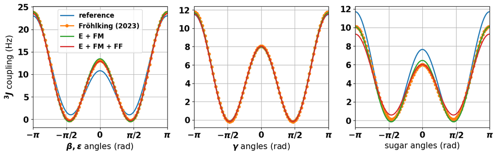

```python
font = {'weight' : 'bold', 'size' : 15}

# plt.rcdefaults()
matplotlib.rc('font', **font)
matplotlib.rcParams['lines.linewidth'] = 2
matplotlib.rcParams['lines.markersize'] = 10

fig, axs = plt.subplots(nrows=1, ncols=3)
fig.set_figheight(4)
fig.set_figwidth(15)

compute_karplus = lambda fm_coeffs, angles, s: fm_coeffs['A_' + s]*np.cos(angles)**2 + fm_coeffs['B_' + s]*np.cos(angles) + fm_coeffs['C_' + s]*np.ones(len(angles))

# plt.suptitle(r'Refinement of Karplus equations $\alpha=%.2f,\beta=%.2f,\gamma=%.2f$' % (opt_alpha, opt_beta, opt_gamma))

angles = np.linspace(-np.pi, np.pi, 100)
titles = [r'$\beta,\epsilon$', r'$\gamma$', 'sugar']

for i,s in enumerate(['beta', 'gamma', 'sugar']):

    karplus = {}

    karplus = compute_karplus(fm_coeffs['original'], angles, s)
    axs[i].plot(angles, karplus, '-', label='reference')

    karplus = compute_karplus(fm_coeffs['Thorben'], angles, s)
    axs[i].plot(angles, karplus, '.-', label='Fröhlking (2023)')

    # karplus = compute_karplus(fm_coeffs['mine 2b'], angles, s)
    # axs[i].plot(angles, karplus, '-', label='optimized 1')

    karplus = compute_karplus(fm_coeffs['mine 2'], angles, s)
    axs[i].plot(angles, karplus, '-', label='E + FM')  # optimized 2')

    karplus = compute_karplus(fm_coeffs['mine'], angles, s)
    axs[i].plot(angles, karplus, '-', label='E + FM + FF')

    # karplus = compute_karplus(fm_coeffs['100 optimal'], angles, s) #  ['mean'], angles, s)
    # axs[i].plot(angles, karplus, '-', label='this study 2') #   (average)')

    # for j in range(n_seeds):
    #     karplus = compute_karplus(fm_coeffs['mine'][j], angles, s)
    #     axs[i].plot(angles, karplus, '-', color='tab:red')#, label='av. mine')


    # for k in ['original', 'mini2', 'mine']:
    #     karplus[k] = fm_coeffs[k]['A_' + s]*np.cos(angles)**2 + fm_coeffs[k]['B_' + s]*np.cos(
    #         angles) + fm_coeffs[k]['C_' + s]*np.ones(len(angles))

    #     axs[i].plot(angles, karplus[k], '-', label=k)

    axs[i].grid()
    axs[i].set_xlabel(titles[i] + ' angles (rad)')
    # axs[0].set_ylim(top=27)
    # axs[i].set_title(titles[i])
    axs[i].set_xlim([-np.pi, np.pi])
    axs[i].set_xticks([-np.pi, -np.pi/2, 0, np.pi/2, np.pi])
    axs[i].set_xticklabels([r'$-\pi$', r'$-\pi/2$', '0', '$\pi/2$', '$\pi$'])

axs[0].legend(fontsize=12)
axs[0].set_ylabel('$^3J$ coupling (Hz)')

# plt.savefig('../../Figures/Karplus_refinement_optimized2.pdf', format='pdf', bbox_inches='tight')
plt.show()
```

```python
my_ff_coeffs = df_result.loc['E+FM+FF ref'][['sin alpha', 'cos alpha']].to_dict()

ff_coeffs = {'this study': my_ff_coeffs,
    'FFR': {'sin alpha': 0.91, 'cos alpha': 1.67},
    'ER+FFR': {'sin alpha': 0.51, 'cos alpha': 1.65}}
```

```python
ff_coeffs
```

```
{'this study': {'sin alpha': 0.5840721894788735,
  'cos alpha': -0.7914544075926866},
 'FFR': {'sin alpha': 0.91, 'cos alpha': 1.67},
 'ER+FFR': {'sin alpha': 0.51, 'cos alpha': 1.65}}
```

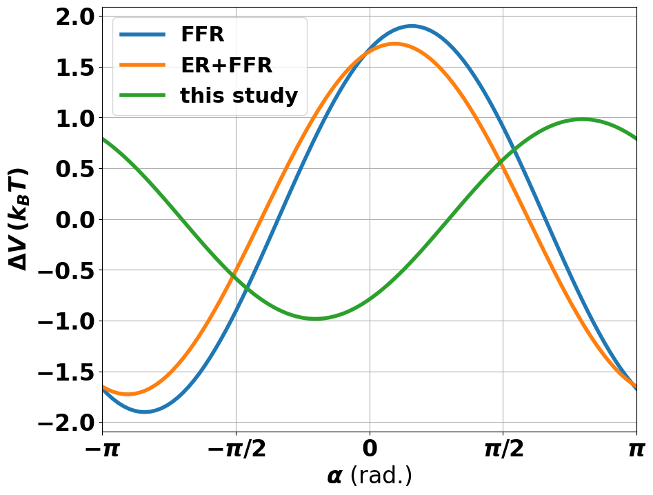

```python
font = {'weight' : 'bold', 'size' : 24}

# plt.rcdefaults()
matplotlib.rc('font', **font)
matplotlib.rcParams['lines.linewidth'] = 4
matplotlib.rcParams['lines.markersize'] = 10

angles = np.linspace(-np.pi, np.pi, 100)

plt.figure(figsize=(10, 8))

deltaV = {}

labels = ['FFR', 'ER+FFR', 'this study']

for i, s in enumerate(labels):
    deltaV[s] = ff_coeffs[s]['cos alpha']*np.cos(angles) + ff_coeffs[s]['sin alpha']*np.sin(angles)

    plt.plot(angles, deltaV[s], '-', label=labels[i])

plt.legend(fontsize=22)
plt.grid()
# plt.title(r'force-field correction $\alpha=%.2f,\beta=%.2f,\gamma=%.2f$' % (opt_alpha, opt_beta, opt_gamma))

plt.xticks([-np.pi, -np.pi/2, 0, np.pi/2, np.pi], ['$-\pi$', '$-\pi/2$', '0', '$\pi/2$', '$\pi$'])
plt.xlim([-np.pi, np.pi])
plt.xlabel(r'$\alpha$ (rad.)')
plt.ylabel('$\Delta V \, (k_B T)$')

# plt.savefig('../../Figures/deltaV.pdf', format='pdf', bbox_inches='tight')
```

#### load dihedral angles and new weights

```python
my_angles = {}

for s in data.properties.system_names:

    my_angles[s] = []
    length = len(data.mol[s].f.T)//2

    for i in range(length):

        angles = np.arcsin(data.mol[s].f[:, i])
        wh = np.argwhere(data.mol[s].f[:, i + length] < 0)
        angles[wh] = np.pi - angles[wh]
        angles = np.mod(angles, 2*np.pi)

        wh = np.argwhere((angles > np.pi) & (angles < 2*np.pi))
        angles[wh] = angles[wh] - 2*np.pi

        my_angles[s].append(angles)
```

```python
weights_new = {}
weights_new['E+FM ref'] = {}
weights_new['E+FM+FF ref ff'] = {}
weights_new['E+FM+FF ref'] = {}

for s in system_names:
    weights_new['E+FM ref'][s] = np.load(path + '/' + my_str + my_list[0] + '/weights_new_%s.npy' % s)
    weights_new['E+FM+FF ref ff'][s] = np.load(path + '/' + my_str + my_list[1] + '/weights_ff_%s.npy' % s)
    weights_new['E+FM+FF ref'][s] = np.load(path + '/' + my_str + my_list[1] + '/weights_new_%s.npy' % s)
```

```python
from MDRefine import compute_new_weights
```

```python
for s2 in ['FFR', 'ER+FFR']:

    pars = np.array(list(ff_coeffs[s2].values()))

    weights_new[s2] = {}

    for s in data.properties.system_names:
        correction = data.mol[s].ff_correction(pars, data.mol[s].f)/data.mol[s].temperature
        weights_new[s2][s] = compute_new_weights(data.mol[s].weights, correction)[0]
```

#### visualize the hypersearch and compare the performances

```python
path = 'Results'
dir_list = os.listdir(path)

my_str = '2_Result_last_2024_10_01'
my_list = [s for s in dir_list if s.startswith(my_str)]

my_str = '2_Result_last_2024_10_03'
my_list = my_list + [s for s in dir_list if s.startswith(my_str)]
```

```python
dfs_hyper = {}
dfs_hyper[0] = pandas.read_csv(path + '/' + my_list[0] + '/' + 'hyper_search', index_col=0)

dfs_hyper[0]
```

|  | av_chi2 | av_gradient alpha | log10_hyperpars alpha | av_gradient gamma | log10_hyperpars gamma |
| --- | --- | --- | --- | --- | --- |
| 0 | 1.494645e+06 | -83484.150525 | 0.000000 | 6864.549112 | 0.000000 |
| 1 | 3.640039e+03 | -7654.440449 | 0.996637 | -1.041580 | -0.081949 |
| 2 | 3.150122e+03 | -2897.590946 | 1.097314 | -28.726717 | -0.081118 |
| 3 | 3.008081e+03 | -1689.717108 | 1.158654 | -25.292575 | -0.079651 |
| 4 | 2.905336e+03 | -756.889430 | 1.244485 | -14.950528 | -0.076566 |
| 5 | 2.863234e+03 | -463.559900 | 1.314144 | -13.941165 | -0.073464 |
| 6 | 2.826691e+03 | -248.580847 | 1.424348 | -14.098655 | -0.065650 |
| 7 | 2.792318e+03 | -167.420569 | 1.552302 | -17.791933 | -0.049322 |
| 8 | 2.799691e+03 | 215.037340 | 1.823207 | -19.598546 | 0.024903 |
| 9 | 2.784123e+03 | -13.669974 | 1.665665 | -19.469618 | -0.018261 |
| 10 | 2.784427e+03 | 2.013717 | 1.679882 | -20.137260 | 0.000477 |
| 11 | 2.784885e+03 | -11.541616 | 1.667584 | -19.664738 | -0.015732 |
| 12 | 2.785748e+03 | -14.214493 | 1.665694 | -19.513599 | -0.018223 |
| 13 | 2.785875e+03 | -11.976166 | 1.665665 | -19.873096 | -0.018261 |
| 14 | 2.784123e+03 | -13.669974 | 1.665665 | -19.469618 | -0.018261 |
| 15 | 2.784123e+03 | -13.669974 | 1.665665 | -19.469618 | -0.018261 |
| 16 | 2.785642e+03 | -13.703361 | 1.665665 | -19.640448 | -0.018261 |
| 17 | 2.784123e+03 | -13.669974 | 1.665665 | -19.469618 | -0.018261 |
| 18 | 2.786297e+03 | -13.187331 | 1.665665 | -19.717498 | -0.018261 |
| 19 | 2.784123e+03 | -13.669974 | 1.665665 | -19.469618 | -0.018261 |

```python
dfs_hyper[1] = pandas.read_csv(path + '/' + my_list[1] + '/hyper_search', index_col=0)

dfs_hyper[1]
```

|  | av_chi2 | av_gradient alpha | log10_hyperpars alpha | av_gradient beta | log10_hyperpars beta | av_gradient gamma | log10_hyperpars gamma |
| --- | --- | --- | --- | --- | --- | --- | --- |
| 0 | 1.492265e+06 | -131752.250461 | 0.000000 | 4309.731730 | 0.000000 | 8201.983928 | 0.000000 |
| 1 | 6.048931e+03 | -1827.753904 | 0.997536 | -2654.318168 | -0.032630 | 363.729927 | -0.062100 |
| 2 | 5.961701e+03 | -2436.721936 | 1.012011 | -2661.525493 | -0.012005 | 354.180727 | -0.064944 |
| 3 | 5.521062e+03 | -4236.963742 | 1.069908 | -2647.068794 | 0.070496 | 297.189956 | -0.076320 |
| 4 | 3.515302e+03 | -4529.681650 | 1.301497 | -1997.389598 | 0.400499 | 89.559859 | -0.121825 |
| 5 | 1.356018e+03 | -792.276702 | 2.227854 | 522.485446 | 1.720510 | -3.889771 | -0.303847 |
| 6 | 1.296206e+03 | 302.932881 | 2.408530 | -625.556200 | 1.679429 | -1.133588 | -0.307227 |
| 7 | 1.256855e+03 | -139.193478 | 2.474971 | -88.051435 | 1.812841 | -1.460127 | -0.321588 |
| 8 | 1.219645e+03 | -221.532270 | 2.679677 | 83.958141 | 2.020229 | -0.960379 | -0.348075 |
| 9 | 1.235216e+03 | -526.791253 | 3.067895 | 863.706156 | 2.368460 | -0.435284 | -0.392212 |
| 10 | 1.206802e+03 | -324.518197 | 2.835539 | 352.205747 | 2.160037 | -0.673070 | -0.365795 |
| 11 | 1.197907e+03 | -125.644071 | 2.925254 | 137.206274 | 2.199433 | -0.439013 | -0.371377 |
| 12 | 1.197224e+03 | 4.202815 | 2.980079 | -7.595233 | 2.222866 | -0.313252 | -0.374685 |
| 13 | 1.196957e+03 | -0.983093 | 2.982219 | 2.209108 | 2.225154 | -0.317014 | -0.374938 |
| 14 | 1.196967e+03 | 2.852635 | 2.981385 | -5.650793 | 2.224404 | -0.307459 | -0.374821 |
| 15 | 1.196718e+03 | 0.631203 | 2.982206 | -1.025570 | 2.225142 | -0.296927 | -0.374936 |
| 16 | 1.197355e+03 | -2.004268 | 2.982046 | 2.182414 | 2.225063 | -0.281948 | -0.374923 |
| 17 | 1.197508e+03 | -0.153537 | 2.982206 | -0.370707 | 2.225142 | -0.304791 | -0.374936 |
| 18 | 1.196718e+03 | 0.631203 | 2.982206 | -1.025570 | 2.225142 | -0.296927 | -0.374936 |
| 19 | 1.197769e+03 | -0.436285 | 2.982206 | 0.328499 | 2.225142 | -0.310074 | -0.374936 |
| 20 | 1.196718e+03 | 0.631203 | 2.982206 | -1.025570 | 2.225142 | -0.296927 | -0.374936 |
| 21 | 1.196494e+03 | -0.089774 | 2.982206 | -0.900691 | 2.225142 | -0.292635 | -0.374936 |
| 22 | 1.197862e+03 | -1.238613 | 2.982206 | 1.333862 | 2.225142 | -0.319871 | -0.374936 |
| 23 | 1.196494e+03 | -0.089774 | 2.982206 | -0.900691 | 2.225142 | -0.292635 | -0.374936 |
| 24 | 1.198168e+03 | -3.917928 | 2.982206 | 4.795175 | 2.225142 | -0.313876 | -0.374936 |
| 25 | 1.196494e+03 | -0.089774 | 2.982206 | -0.900691 | 2.225142 | -0.292635 | -0.374936 |
| 26 | 1.197684e+03 | -2.063023 | 2.982206 | 3.488448 | 2.225142 | -0.318867 | -0.374936 |
| 27 | 1.196494e+03 | -0.089774 | 2.982206 | -0.900691 | 2.225142 | -0.292635 | -0.374936 |
| 28 | 1.198466e+03 | -3.022926 | 2.982206 | 3.451009 | 2.225142 | -0.312440 | -0.374936 |
| 29 | 1.196494e+03 | -0.089774 | 2.982206 | -0.900691 | 2.225142 | -0.292635 | -0.374936 |
| 30 | 1.195601e+03 | 0.584198 | 2.982206 | 0.204075 | 2.225144 | -0.321880 | -0.374936 |
| 31 | 1.198376e+03 | -2.342956 | 2.982206 | 2.408318 | 2.225143 | -0.290420 | -0.374935 |
| 32 | 1.197225e+03 | -1.069302 | 2.982206 | 1.167798 | 2.225144 | -0.323852 | -0.374936 |
| 33 | 1.195601e+03 | 0.584198 | 2.982206 | 0.204075 | 2.225144 | -0.321880 | -0.374936 |
| 34 | 1.197135e+03 | 1.064044 | 2.982206 | -2.768780 | 2.225144 | -0.291808 | -0.374936 |
| 35 | 1.195601e+03 | 0.584198 | 2.982206 | 0.204075 | 2.225144 | -0.321880 | -0.374936 |
| 36 | 1.198524e+03 | -0.938316 | 2.982206 | 0.128946 | 2.225144 | -0.295471 | -0.374936 |
| 37 | 1.195601e+03 | 0.584198 | 2.982206 | 0.204075 | 2.225144 | -0.321880 | -0.374936 |
| 38 | 1.196534e+03 | 0.173934 | 2.982206 | -1.522654 | 2.225144 | -0.308666 | -0.374936 |
| 39 | 1.195601e+03 | 0.584198 | 2.982206 | 0.204075 | 2.225144 | -0.321880 | -0.374936 |
| 40 | 1.196368e+03 | -0.171807 | 2.982206 | -1.025771 | 2.225144 | -0.316227 | -0.374936 |
| 41 | 1.195601e+03 | 0.584198 | 2.982206 | 0.204075 | 2.225144 | -0.321880 | -0.374936 |
| 42 | 1.195591e+03 | 1.746340 | 2.982206 | -1.951944 | 2.225144 | -0.303722 | -0.374936 |
| 43 | 1.195916e+03 | 3.862034 | 2.982206 | -4.850452 | 2.225144 | -0.311755 | -0.374936 |
| 44 | 1.195591e+03 | 1.746340 | 2.982206 | -1.951944 | 2.225144 | -0.303722 | -0.374936 |

```python
print(10**dfs_hyper[0].iloc[-1][['log10_hyperpars alpha', 'log10_hyperpars gamma']])

print(10**dfs_hyper[1].iloc[-1][['log10_hyperpars alpha', 'log10_hyperpars beta', 'log10_hyperpars gamma']])
```

```
log10_hyperpars alpha    46.308959
log10_hyperpars gamma     0.958824
Name: 19, dtype: float64
log10_hyperpars alpha    959.856495
log10_hyperpars beta     167.935942
log10_hyperpars gamma      0.421759
Name: 44, dtype: float64
```

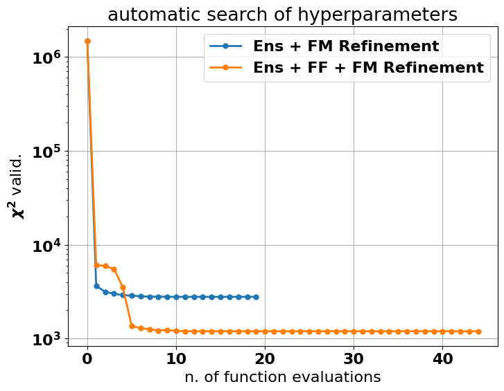

```python
font = {'weight' : 'bold', 'size' : 16}

# plt.rcdefaults()
matplotlib.rc('font', **font)
matplotlib.rcParams['lines.linewidth'] = 2
matplotlib.rcParams['lines.markersize'] = 10

plt.figure(figsize=(8, 6))
plt.plot(dfs_hyper[0]['av_chi2'], '.-', label='Ens + FM Refinement')
plt.plot(dfs_hyper[1]['av_chi2'], '.-', label='Ens + FF + FM Refinement')

plt.yscale('log')
plt.grid()
plt.xlabel('n. of function evaluations')
plt.ylabel(r'$\chi^2$ valid.')
plt.title('automatic search of hyperparameters')
plt.legend()

# plt.savefig('../../Figures/hyper_search.pdf', format='pdf', bbox_inches='tight')
```

#### histograms

- alpha dihedral angles

```python
bins = np.arange(-np.pi, np.pi, 0.05)
my_list = ['original'] + list(weights_new.keys())

my_hists = {}

for s in my_list:
    my_hists[s] = {}
    for s2 in data.properties.system_names:
        my_hists[s][s2] = []

for s in data.properties.system_names:
    for i in range(len(my_angles[s])):
        my_hists['original'][s].append(np.histogram(my_angles[s][i], bins=bins, density=True))
        for s2 in my_list[1:]:
            my_hists[s2][s].append(np.histogram(my_angles[s][i], bins=bins, density=True, weights=weights_new[s2][s]))
```

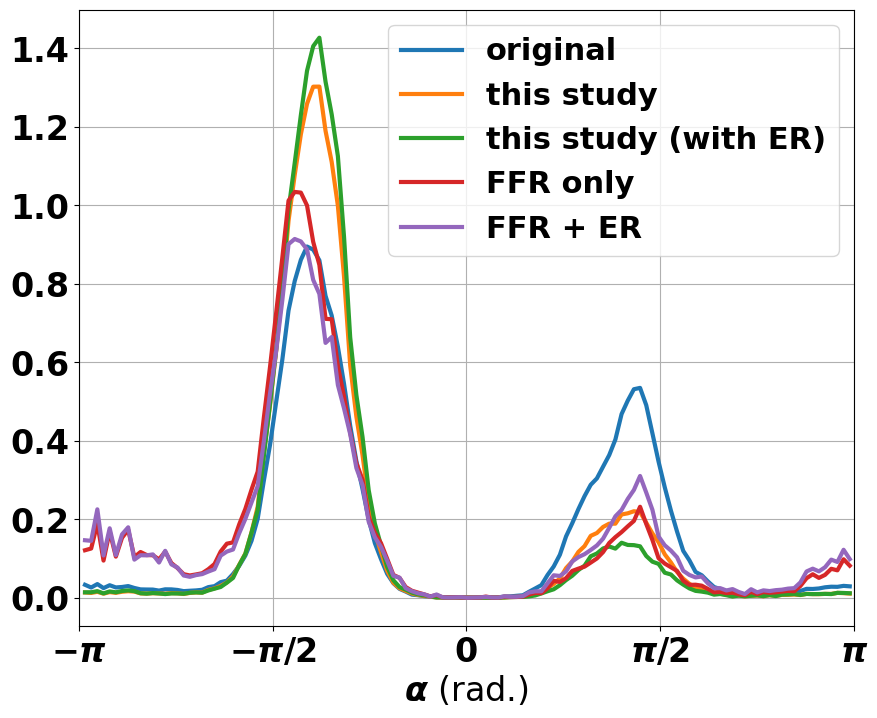

```python
font = {'weight' : 'bold', 'size' : 24}
matplotlib.rc('font', **font)

plt.figure(figsize=(10, 8))

tot_hist = {}

for s2 in my_list: tot_hist[s2] = np.zeros(len(my_hists['original']['AAAA'][0][0]))

counter = 0

for s in data.properties.system_names:
    for i in range(len(my_hists['original'][s])):
        for s2 in my_list:
            tot_hist[s2] += my_hists[s2][s][i][0]
        counter += 1

labels = ['original', 'this study', 'this study (with ER)', 'FFR only', 'FFR + ER']

x = my_hists['original'][s][i][1][1:]

# tot_hist['original'] = tot_hist['original']/counter
# plt.fill_between(x, np.zeros(len(x)), tot_hist['original'], alpha=0.4, label='original')

labels = ['original', 'this study', 'this study (with ER)', 'FFR only', 'FFR + ER']
my_sublist = ['original', 'E+FM+FF ref ff', 'E+FM+FF ref', 'FFR', 'ER+FFR']

# for i, s2 in enumerate(my_list):
for i, s2 in enumerate(my_sublist):
    tot_hist[s2] = tot_hist[s2]/counter

    # if i == 1: lw = 5
    # else: lw = 2
    lw = 3

    # plt.plot(my_hists['original'][s][i][1][1:], my_hists[s2]['AAAA'][0][0])
    plt.plot(x, tot_hist[s2], '-', label=labels[i], linewidth=lw)
    # plt.fill_between(x, np.zeros(len(x)), tot_hist[s2], alpha=0.6)

plt.xticks([-np.pi, -np.pi/2, 0, np.pi/2, np.pi], ['$-\pi$', '$-\pi/2$', '0', '$\pi/2$', '$\pi$'])
plt.xlim([-np.pi, np.pi])
plt.xlabel(r'$\alpha$ (rad.)')
plt.legend(fontsize=22)
plt.grid()

# plt.savefig('../../Figures/tot_hist_alpha.pdf', format='pdf', bbox_inches='tight')
```

- forward-model dihedral angles

```python
bins = np.arange(-np.pi, np.pi, 0.05)
# bins = np.arange(0, 20, 0.5)  # bins for the histograms of the 3J couplings

my_hists_fm = {}

for s in my_list:
    my_hists_fm[s] = {}
    for s2 in data.properties.system_names:
        my_hists_fm[s][s2] = {}
        for s3 in data.mol[s2].forward_qs.keys():
            my_hists_fm[s][s2][s3] = []

for s in data.properties.system_names:
    for s2 in data.mol[s].forward_qs.keys():
        for i in range(data.mol[s].forward_qs[s2].shape[1]):
            my_hists_fm['original'][s][s2].append(np.histogram(data.mol[s].forward_qs[s2][:, i], bins=bins, density=True))
            for s3 in my_list[1:]:
                my_hists_fm[s3][s][s2].append(np.histogram(data.mol[s].forward_qs[s2][:, i], bins=bins, density=True, weights=weights_new[s3][s]))
```

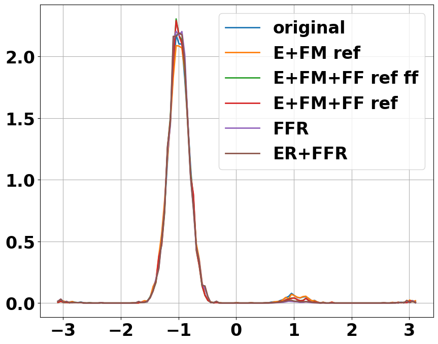

```python
plt.figure(figsize=(10, 8))

for s in my_list:
    my_var = my_hists_fm[s]['AAAA']['backbone1_gamma'][2]
    plt.plot(my_var[1][1:], my_var[0], '-', label=s)

plt.legend()
plt.grid()
```

#### relative entropy and chi2

```python
def plot_DataFrame(df, labels=None, xticks_name=None):

        barWidth = 1/(len(df.columns) + 1)

        plt.subplots(figsize=(12, 8))

        brs = []
        brs.append(np.arange(len(df.iloc[:, 0])))

        if labels == None: labels = df.columns
        if xticks_name == None: xticks_name = list(df.index)

        plt.bar(brs[-1], df.iloc[:, 0], label=labels[0], width=barWidth)  # edgecolor ='grey', color ='tab:blue')

        for i in range(1, len(df.columns)):
                brs.append([x + barWidth for x in brs[-1]])
                plt.bar(brs[-1], df.iloc[:, i], label=labels[i], width=barWidth)  # edgecolor ='grey', color ='tab:blue')

        plt.xticks([r + barWidth*(len(df.columns) - 1)/2 for r in range(len(df.iloc[:, 0]))], xticks_name)
        # plt.xticks([r + barWidth for r in range(len(df.iloc[:, 0]))], list(df.index))
        # plt.xlabel(list(df.index))

        # plt.xlabel('Branch', fontweight ='bold', fontsize = 15)
        # plt.ylabel('Students passed', fontweight ='bold', fontsize = 15)
        # plt.xticks([r + barWidth for r in range(len(df['Aduri'].iloc[:-1]))], names_charges)

        plt.legend()
        plt.gca().xaxis.grid(True)
        # plt.grid()
        # plt.show()

        return
```

```python
my_cols = [col for col in my_df.columns if col.startswith('D_KL_alpha')]
my_cols1 = [col for col in my_df.columns if col.startswith('reg_ff')]

my_df[my_cols1]
```

|  | reg_ff_AAAA | reg_ff_CAAU | reg_ff_CCCC | reg_ff_GACC | reg_ff_UUUU | reg_ff_UCAAUC |
| --- | --- | --- | --- | --- | --- | --- |
| 2024_10_03_12_35_46_920644 | 0.346839 | 0.570094 | 0.523402 | 0.260561 | 0.392336 | 0.466149 |
| 2024_10_01_13_36_53_483051 | NaN | NaN | NaN | NaN | NaN | NaN |

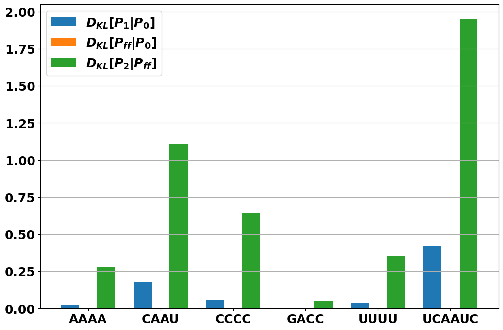

```python
font = {'weight' : 'bold', 'size' : 18}

# plt.rcdefaults()
matplotlib.rc('font', **font)
matplotlib.rcParams['lines.linewidth'] = 2
matplotlib.rcParams['lines.markersize'] = 10

my_dict = {'DKL ER': my_df[my_cols].iloc[0].values, 'DKL FFR': my_df[my_cols1].iloc[1].values, 'DKL ER from FFR': my_df[my_cols].iloc[1].values}

df = pandas.DataFrame(my_dict, index=system_names)

plt.figure(figsize=(4, 4))
plot_DataFrame(df, labels=[r'$D_{KL}[P_1|P_0]$', r'$D_{KL}[P_{ff}|P_0]$', r'$D_{KL}[P_2|P_{ff}]$'])
plt.legend()
plt.grid()

# plt.savefig('../../Figures/rel_entropies.pdf', format='pdf', bbox_inches='tight')
```

[figure not shown]

```python
x = np.arange(6)

font = {'weight' : 'bold', 'size' : 12}

# plt.rcdefaults()
matplotlib.rc('font', **font)
matplotlib.rcParams['lines.linewidth'] = 2
matplotlib.rcParams['lines.markersize'] = 10

plt.plot(x, my_df[my_cols].iloc[0], '.', label='-S[P|P0] for E+FM ref')
plt.plot(x, my_df[my_cols].iloc[1], '.', label='-S[P|P_\phi] for E+FM+FF ref')
plt.plot(x, my_df[my_cols1].iloc[1], '.', label='-S[P_\phi|P0] for E+FM+FF ref')

plt.xticks(x, system_names)
plt.legend()
plt.grid()

# plt.savefig('../../Figures/rel_entropies.pdf', format='pdf', bbox_inches='tight')
```

```python
def compute_DKL(w, w0):
    out = np.sum(w[w != 0]*np.log(w[w != 0]/w0[w != 0]))
    return out
```

the critical issue when computing the relative entropy from the histogram weights is that you have to select a single dihedral angle, unless you act on the "average histogram", which might be not significatively enough, due to the curse of dimensionality! You could/should compute the rel. entropy for each dihedral angle and then compare the average values...

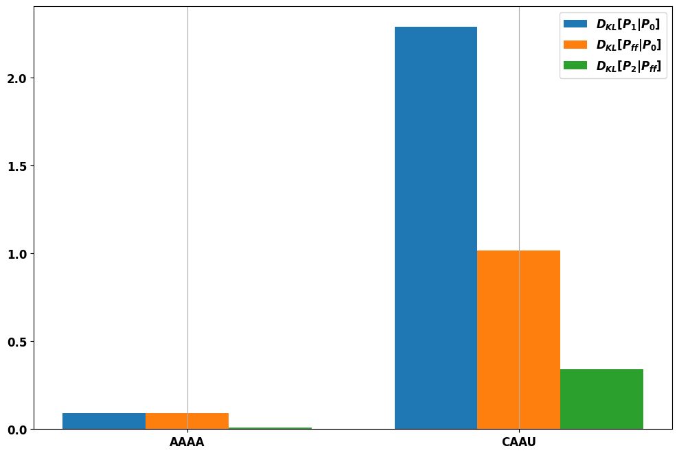

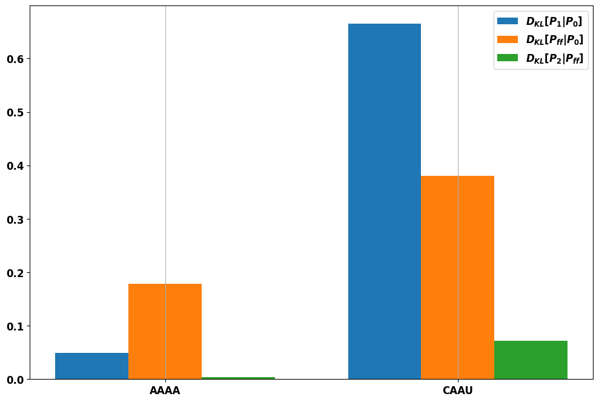

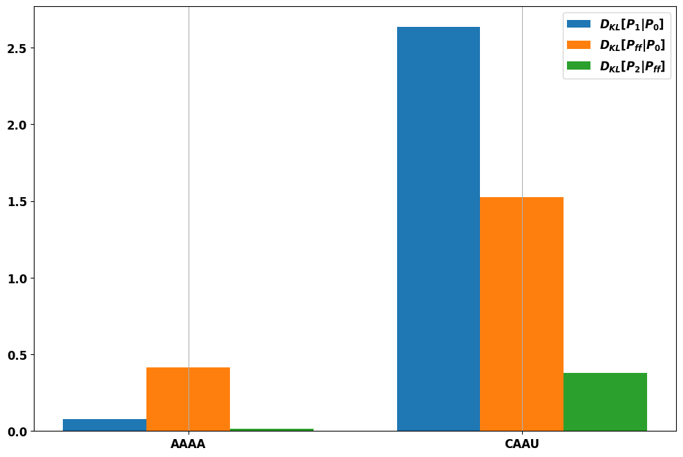

```python
my_dict = {}

kinds = ['backbone1_gamma', 'backbone2_beta_epsilon', 'sugar']

for kind in kinds:

    for s in my_hists_fm['E+FM+FF ref ff'].keys():

        w0 = my_hists_fm['original'][s][kind][1][0]
        w_fm = my_hists_fm['E+FM ref'][s][kind][1][0]
        w_ff = my_hists_fm['E+FM+FF ref ff'][s][kind][1][0]
        w = my_hists_fm['E+FM+FF ref'][s][kind][1][0]

        my_dict[s] = [compute_DKL(w_fm, w0), compute_DKL(w_ff, w0), compute_DKL(w, w_ff)]

    this_df = pandas.DataFrame(my_dict).T

    plot_DataFrame(this_df, labels=[r'$D_{KL}[P_1|P_0]$', r'$D_{KL}[P_{ff}|P_0]$', r'$D_{KL}[P_2|P_{ff}]$'])
```

```python
my_cols = ['optimal alpha', 'optimal beta', 'optimal gamma']

print('ER+FMR:\n', df_result.loc['E+FM ref'][[s for s in my_cols if s in df_result.columns]])

print('\n\nfully combined:\n', df_result.loc['E+FM+FF ref'][[s for s in my_cols if s in df_result.columns]])

cols = [s for s in df_result.columns if s.startswith('D_KL_alpha') or s.startswith('reg_ff')]
print('\n', df_result[cols])
```

```
ER+FMR:
 optimal alpha    46.308959
optimal beta           NaN
optimal gamma     0.958824
Name: E+FM ref, dtype: object


fully combined:
 optimal alpha    959.856495
optimal beta     167.935942
optimal gamma      0.421759
Name: E+FM+FF ref, dtype: object

              reg_ff_AAAA  reg_ff_CAAU  reg_ff_CCCC  reg_ff_GACC  reg_ff_UUUU  \
E+FM+FF ref     0.346839     0.570094     0.523402     0.260561     0.392336
E+FM ref             NaN          NaN          NaN          NaN          NaN

             reg_ff_UCAAUC  D_KL_alpha_AAAA  D_KL_alpha_CAAU  D_KL_alpha_CCCC  \
E+FM+FF ref       0.466149         0.021830         0.181029         0.052605
E+FM ref               NaN         0.276919         1.109998         0.645304

             D_KL_alpha_GACC  D_KL_alpha_UUUU  D_KL_alpha_UCAAUC
E+FM+FF ref         0.000185         0.039078           0.422813
E+FM ref            0.052310         0.355849           1.951061
```

```python
from MDRefine import compute_chi2
```

```python
s1_list = list(weights_new.keys())
print(s1_list)

chi2_values = {}

for s1 in s1_list:
    chi2_values[s1] = {}
    for s in data.properties.system_names:
        chi2_values[s1][s] = compute_chi2(data.mol[s].ref, weights_new[s1][s], data.mol[s].g, data.mol[s].gexp)[1]
```

```
['E+FM ref', 'E+FM+FF ref ff', 'E+FM+FF ref', 'FFR', 'ER+FFR']
```

```python
chi2_values['original'] = {}

for s in data.properties.system_names:
    chi2_values['original'][s] = compute_chi2(data.mol[s].ref, data.mol[s].weights, data.mol[s].g, data.mol[s].gexp)[1]
```

```python
for s in data.properties.system_names:
    print(data.mol[s].n_experiments)
```

```
{'backbone1_gamma_3J': 8, 'backbone2_beta_epsilon_3J': 9, 'sugar_3J': 11, 'NOEs': 36}
{'backbone1_gamma_3J': 8, 'backbone2_beta_epsilon_3J': 8, 'sugar_3J': 11, 'NOEs': 39}
```

```python
chi2s = {}

for s1 in ['original'] + s1_list:
    chi2s[s1] = {}
    for s2 in chi2_values[s1][s].keys():
        chi2s[s1][s2] = np.sum([chi2_values[s1][s][s2] for s in data.properties.system_names])
```

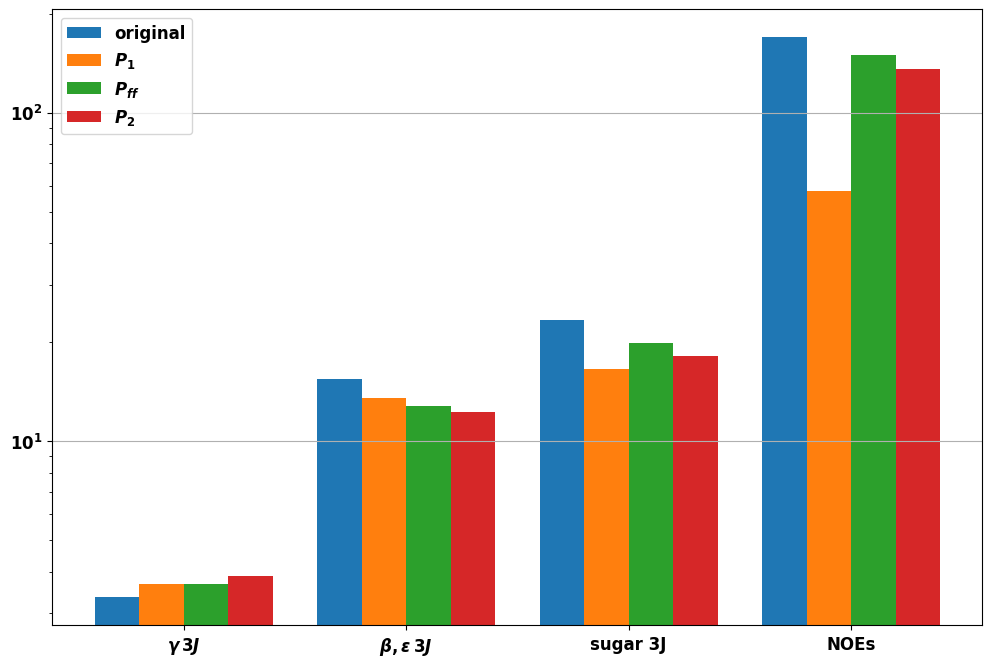

```python
chi2s_df = pandas.DataFrame(chi2s)
xticks_name = ['$\gamma \, 3J$', r'$\beta, \epsilon \, 3J$', 'sugar 3J', 'NOEs']  # , 'uNOEs']

plot_DataFrame(chi2s_df.iloc[:, :-2], labels=['original', '$P_1$', '$P_{ff}$', '$P_2$'], xticks_name=xticks_name)
plt.yscale('log')
plt.grid()

# plt.savefig('../../Figures/chi2s.pdf', format='pdf', bbox_inches='tight')
```

##### other histograms

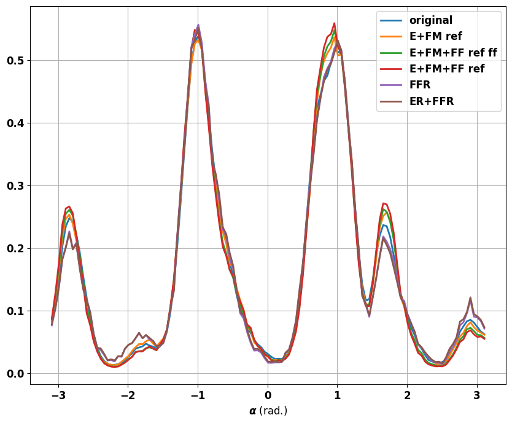

```python
plt.figure(figsize=(10, 8))

tot_hist = {}

for s2 in my_list: tot_hist[s2] = np.zeros(len(my_hists_fm['original']['AAAA']['backbone1_gamma'][0][0]))

counter = 0

for s in data.properties.system_names:
    for s1 in my_hists_fm['original'][s].keys():
        for i in range(len(my_hists_fm['original'][s][s1])):
            for s2 in my_list:
                tot_hist[s2] += my_hists_fm[s2][s][s1][i][0]
            counter += 1

# labels = ['original', 'this study', 'this study (with ER)', 'FFR only', 'FFR + ER']

x = my_hists_fm['original'][s][s1][i][1][1:]

# tot_hist['original'] = tot_hist['original']/counter
# plt.fill_between(x, np.zeros(len(x)), tot_hist['original'], alpha=0.4, label='original')

for i, s2 in enumerate(my_list):
    tot_hist[s2] = tot_hist[s2]/counter

    # if i == 1: lw = 5
    # else:
    lw = 2

    # plt.plot(my_hists_fm['original'][s][i][1][1:], my_hists_fm[s2]['AAAA'][0][0])
    plt.plot(x, tot_hist[s2], '-', label=s2, linewidth=lw)
    # plt.fill_between(x, np.zeros(len(x)), tot_hist[s2], alpha=0.6)

# plt.xticks([-np.pi, -np.pi/2, 0, np.pi/2, np.pi], ['$-\pi$', '$-\pi/2$', '0', '$\pi/2$', '$\pi$'])
# plt.xlim([-np.pi, np.pi])
plt.xlabel(r'$\alpha$ (rad.)')
plt.legend()
plt.grid()

# plt.savefig('../../Figures/tot_hist_Karplus_angles.pdf', format='pdf', bbox_inches='tight')
```

```python
print([np.max(data.mol[s].g['NOEs']) for s in data.properties.system_names])

bins = np.arange(-0.001, 0.05, 0.001)

my_hists_NOEs = {}

for s in my_list:
    my_hists_NOEs[s] = {}
    for s2 in data.properties.system_names:
        my_hists_NOEs[s][s2] = []

for s in data.properties.system_names:
    for i in range(data.mol[s].g['NOEs'].shape[1]):
        my_hists_NOEs['original'][s].append(np.histogram(data.mol[s].g['NOEs'][:, i], bins=bins, density=True))
        for s3 in my_list[1:]:
            my_hists_NOEs[s3][s].append(np.histogram(data.mol[s].g['NOEs'][:, i], bins=bins, density=True, weights=weights_new[s3][s]))
```

```
[Array(0.03321244, dtype=float32), Array(0.03575967, dtype=float32)]
```

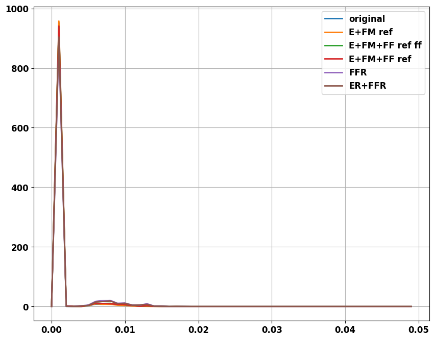

```python
plt.figure(figsize=(10, 8))

for s in my_list:
    # for s2 in infos['global']['system_names']:
    my_var = my_hists_NOEs[s]['CAAU'][0]
    plt.plot(my_var[1][1:], my_var[0], '-', label=s)

plt.legend()
plt.grid()
```

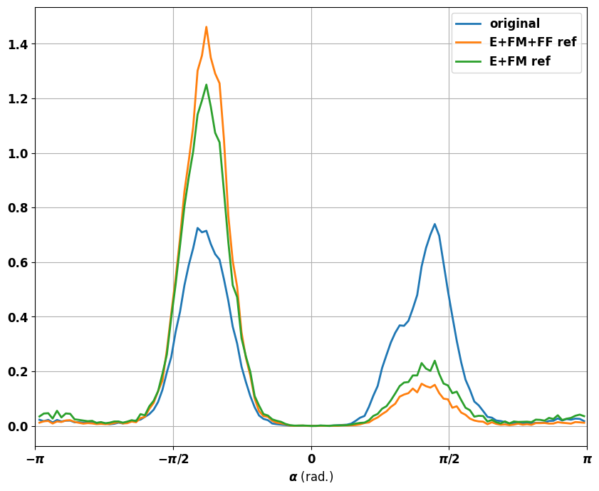

```python
s = 'CAAU'

plt.figure(figsize=(10, 8))

x = my_hists['original'][s][0][1][1:]

for s2 in ['original', 'E+FM+FF ref', 'E+FM ref']:
    hist = np.mean(np.array([my_hists[s2][s][i][0] for i in range(len(my_hists['original'][s]))]), axis=0)
    plt.plot(x, hist, label=s2)

# plt.plot(x, my_hists['original'][s][1][0], label='E+FM+FF ref')
# plt.plot(x, my_hists['E+FM+FF ref'][s][1][0], label='E+FM+FF ref')
# plt.plot(x, my_hists['E+FM ref'][s][1][0], label='E+FM ref')

plt.xticks([-np.pi, -np.pi/2, 0, np.pi/2, np.pi], ['$-\pi$', '$-\pi/2$', '0', '$\pi/2$', '$\pi$'])
plt.xlim([-np.pi, np.pi])
plt.xlabel(r'$\alpha$ (rad.)')
plt.legend()
plt.grid()
```

[output not shown]

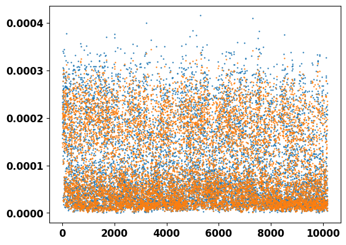

```python
print(weights_new.keys())

s2 = 'E+FM+FF ref ff'
s = 'AAAA'

plt.plot(weights_new['E+FM+FF ref'][s], '.', markersize=1.5)
plt.plot(weights_new[s2][s], '.', markersize=1.5)

plt.figure()
```

[output not shown]

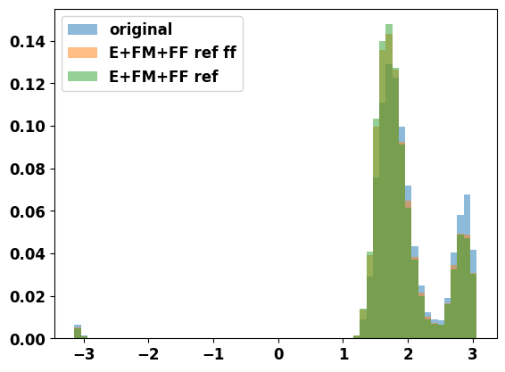

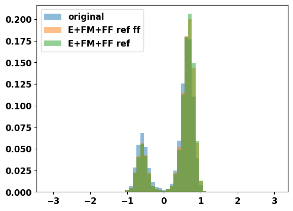

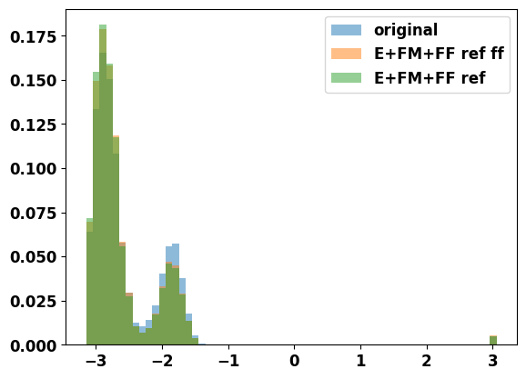

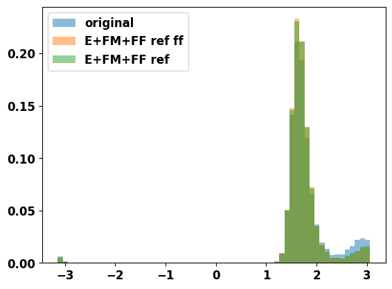

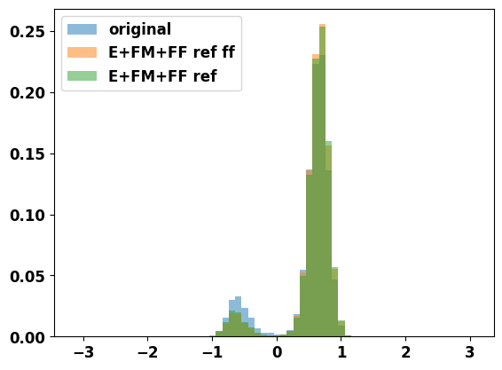

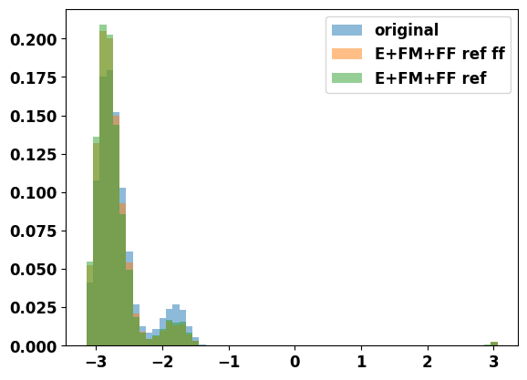

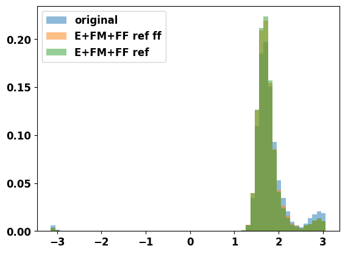

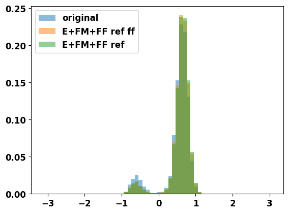

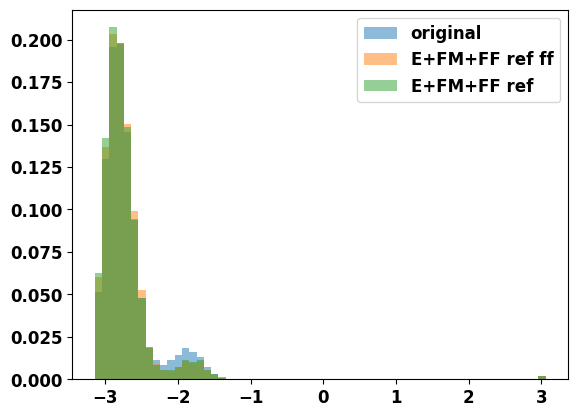

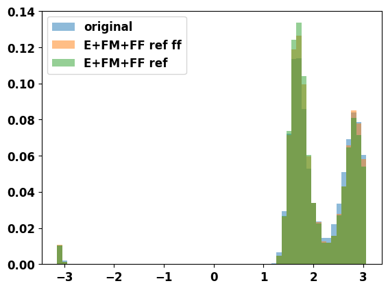

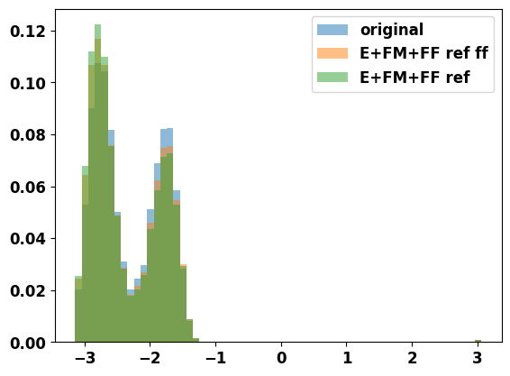

```python
print(data.mol[s].forward_qs.keys())

angles = data.mol[s].forward_qs['sugar']
bins = np.arange(-np.pi, np.pi, 0.1)

for i in range(angles.shape[1]):
    plt.figure()
    plt.hist(angles[:, i], bins, weights=data.mol[s].weights, alpha=0.5, label='original')[2]
    plt.hist(angles[:, i], bins, weights=weights_new['E+FM+FF ref ff'][s], alpha=0.5, label='E+FM+FF ref ff')[2]
    plt.hist(angles[:, i], bins, weights=weights_new['E+FM+FF ref'][s], alpha=0.5, label='E+FM+FF ref')[2]
    plt.legend()
```